# R for microbiology & oceanography

Sarah Hu

7/17/2022

# 1 Introduction

Requirements: * Base understanding of the R programming language * tidyverse R library * Background reading on processes and concepts in microbial ecology

## 1.1 Learning R

–software carpentry introduction to R material

## 1.2 Marine microbial ecology

# 2 Quantifying microorganisms in the ocean

**Goal**: Understand how microorganisms are counted and quantified, using samples from the natural environment and laboratory cultures.

## 2.1 Methods in counting microbes from natural samples

–cells/ml –why is this important? –cells / ml in a paper –cells/ml in different environments –microscopy and epifluoreecent staining, etc. –cells/ml equation
$$Cells/ml =
\frac{(MeanCellsFOV)(AreaChamber)}{(AreaFOV)(Volume)(DilutionFactor)}$$
$$Area = µm^2$$
$$Volume = ml$$
Area of Field of View(FOV) or counting grid will vary depending on the microscope you are using and the magnification. When you are preparing slides, find information on the area of the filter chamber.

## 2.2 Import data from cell counts

Open the below data sets outside of RStudio and calculate cells/ml for Sample03 in Excel. Repeat below in R.

```r
raw_cell_counts <- read.csv("input-data/raw-cell-counts.csv")
```

```r
library(tidyverse)
```

### 2.2.1 Process cell count data

Calculate cells/ml for Sample03. Sample03 was counted at 100x magnification. The area of the funnel used to create the slide has a radius of 8E3 mm. 2 ml of Sample was fixed with formaldehyde at a final concentration of 1%, all of it was filtered onto a 0.2µm filter and stained with DAPI. The counting grid used for each FOV has an area of 1E4 µm^2.

```r
# 1. Isolate sample03 as set of numbers, calculate the average
sample3 <- raw_cell_counts %>%
  select(Sample03) %>%
  summarise(MEAN = mean(Sample03))

sample3_mean <- sample3[1,1]
```

```r
# 2. write equation from above in R, define variables as R objects as needed.
Mean_cells_per_FOV <- sample3_mean # from average
Area_chamber <- (pi)*(((8E3)*(1000))^2) #µm^2
Volume <- 2 #ml
Area_FOV <- 1E4 #µm^2 at 100X magnification
Dilution_factor <- 0.9

cells_per_ml <- ((Mean_cells_per_FOV)*(Area_chamber))/((Volume)*(Area_FOV)*(Dilution_factor))
cells_per_ml # raw number
```

```
## [1] 27925268032
```

```r
format(cells_per_ml, scientific = TRUE, digits = 3) # formatted as scientific
```

```
## [1] "2.79e+10"
```

#### 2.2.1.1 Apply to all data

```r
head(raw_cell_counts)
```

```
##   Sample01 Sample02 Sample03 Sample04 Sample05 Sample06 Sample07 Sample08
## 1       12        7        0        7       18        5       23       11
## 2       14        4        0        9       14        6       21       11
## 3        9        6        3       11       14        9       18        9
## 4        8        9        2       14       20       11       29        8
## 5       20       11        6        8       17       12       31       16
## 6       17       13        1        4        9        9       22       13
```

Use tidyverse to modify the data frame and make an output table with cells per ml for each sample.

```r
raw_cell_counts %>%
  # Transform to long format
  pivot_longer(cols = starts_with("Sample"), names_to = "SAMPLE", values_to = "CELL_per_FOV") %>%
  # Estimate average cells per FOV and variance for each count
  group_by(SAMPLE) %>%
  summarise(MEAN = mean(CELL_per_FOV), VAR = var(CELL_per_FOV)) %>%
  # use mutate and copy above equation to calculate cells per ml
  mutate(CELLS_PER_ML = ((MEAN)*(Area_chamber))/((Volume)*(Area_FOV)*(Dilution_factor))) %>%
  # Option to add column with same values in scientific
  mutate(SCI_cells_per_ml = format(CELLS_PER_ML, scientific = TRUE, digits = 3))
```

```
## # A tibble: 8 × 5
##   SAMPLE    MEAN   VAR  CELLS_PER_ML SCI_cells_per_ml
##   <chr>    <dbl> <dbl>         <dbl> <chr>
## 1 Sample01  13.1 24.1  146328404487. 1.46e+11
## 2 Sample02   7.9  8.32  88243846981. 8.82e+10
## 3 Sample03   2.5  6.94  27925268032. 2.79e+10
## 4 Sample04   9.3  9.79 103881997079. 1.04e+11
## 5 Sample05  15.1 19.9  168668618913. 1.69e+11
## 6 Sample06   9    5.33 100530964915. 1.01e+11
## 7 Sample07  23.3 23.1  260263498057. 2.60e+11
## 8 Sample08  11.3  8.23 126222211504. 1.26e+11
```

##### 2.2.1.1.1 Exercise: What is the best way to show these data in a plot?

```r
# raw_cell_counts %>%
#   pivot_longer(cols = starts_with("Sample"), names_to = "SAMPLE", values_to = "CELL_per_FOV") %>%
#   group_by(SAMPLE) %>%
#   summarise(MEAN = mean(CELL_per_FOV), VAR = var(CELL_per_FOV)) %>%
#   mutate(CELLS_PER_ML = ((MEAN)*(Area_chamber))/((Volume)*(Area_FOV)*(Dilution_factor))) %>%
#   mutate(SCI_cells_per_ml = format(CELLS_PER_ML, scientific = TRUE, digits = 3)) %>%
# ggplot(aes(x = SAMPLE, y = CELLS_PER_ML)) +
#   geom_???
```

### 2.2.2 Estimate growth rate

Import another set of cell count data and metadata. Combine to make a plot of the growth curve.

```r
cell_counts_01 <- read.csv("input-data/cell-count-data01.csv")
metadata_01 <- read.csv("input-data/sample-info-data01.csv")
```

Apply above code again to calculate cells per ml for each sample

```r
# head(cell_counts_01) # rename some of the variable so it is applicable to these new data.
cell_counts_01 %>%
  pivot_longer(cols = starts_with("X"), names_to = "SAMPLE", values_to = "CELL_per_FOV") %>%
  group_by(SAMPLE) %>%
  summarise(MEAN = mean(CELL_per_FOV), VAR = var(CELL_per_FOV)) %>%
  mutate(CELLS_PER_ML = ((MEAN)*(Area_chamber))/((Volume)*(Area_FOV)*(Dilution_factor))) %>%
  mutate(SCI_cells_per_ml = format(CELLS_PER_ML, scientific = TRUE, digits = 3))
```

```
## # A tibble: 14 × 5
##    SAMPLE  MEAN   VAR  CELLS_PER_ML SCI_cells_per_ml
##    <chr>  <dbl> <dbl>         <dbl> <chr>
##  1 X0_A     2.2  4.18  24574235868. 2.46e+10
##  2 X0_B     2.9  7.21  32393310917. 3.24e+10
##  3 X1_A     1.9  4.32  21223203704. 2.12e+10
##  4 X1_B     2.1  3.43  23457225147. 2.35e+10
##  5 X2_A     3    5.78  33510321638. 3.35e+10
##  6 X2_B     2.9  4.1   32393310917. 3.24e+10
##  7 X3_A     7.3  6.23  81541782653. 8.15e+10
##  8 X3_B     6.1  5.43  68137653998. 6.81e+10
##  9 X4_A     8.7  7.57  97179932751. 9.72e+10
## 10 X4_B     9.2 16.8  102764986357. 1.03e+11
## 11 X5_A    10.4 10.7  116169115013. 1.16e+11
## 12 X5_B    11.3  9.34 126222211504. 1.26e+11
## 13 X6_A    10    9.78 111701072128. 1.12e+11
## 14 X6_B    11.5 10.5  128456232947. 1.28e+11
```

There are a few data wrangling steps we need to take now. The final goal though, is to be able to look at the A vs B reps for each sample. And we need to fix the error where R places an “X” preceding a numeric (see “SAMPLE” above).

```r
head(metadata_01)
```

```
##   sample_id   date hour magnification
## 1       0_A 7/4/22    0           100
## 2       0_B 7/4/22    0           100
## 3       1_A 7/4/22    6           100
## 4       1_B 7/4/22    6           100
## 5       2_A 7/4/22   12           100
## 6       2_B 7/4/22   12           100
```

```r
cell_counts_01 %>%
  pivot_longer(cols = starts_with("X"), names_to = "SAMPLE", values_to = "CELL_per_FOV") %>%
  group_by(SAMPLE) %>%
  summarise(MEAN = mean(CELL_per_FOV), VAR = var(CELL_per_FOV)) %>%
  mutate(CELLS_PER_ML = ((MEAN)*(Area_chamber))/((Volume)*(Area_FOV)*(Dilution_factor))) %>%
  mutate(SCI_cells_per_ml = format(CELLS_PER_ML, scientific = TRUE, digits = 3)) %>%
  # Fix SAMPLE names and separate into samples and replicates
  separate(SAMPLE, into = c("SAMPLE_NAME", "REP"), sep = "_", remove = FALSE) %>%
  mutate(SAMPLE = gsub("X","", SAMPLE)) # edits the SAMPLE cell.
```

```
## # A tibble: 14 × 7
##    SAMPLE SAMPLE_NAME REP    MEAN   VAR  CELLS_PER_ML SCI_cells_per_ml
##    <chr>  <chr>       <chr> <dbl> <dbl>         <dbl> <chr>
##  1 0_A    X0          A       2.2  4.18  24574235868. 2.46e+10
##  2 0_B    X0          B       2.9  7.21  32393310917. 3.24e+10
##  3 1_A    X1          A       1.9  4.32  21223203704. 2.12e+10
##  4 1_B    X1          B       2.1  3.43  23457225147. 2.35e+10
##  5 2_A    X2          A       3    5.78  33510321638. 3.35e+10
##  6 2_B    X2          B       2.9  4.1   32393310917. 3.24e+10
##  7 3_A    X3          A       7.3  6.23  81541782653. 8.15e+10
##  8 3_B    X3          B       6.1  5.43  68137653998. 6.81e+10
##  9 4_A    X4          A       8.7  7.57  97179932751. 9.72e+10
## 10 4_B    X4          B       9.2 16.8  102764986357. 1.03e+11
## 11 5_A    X5          A      10.4 10.7  116169115013. 1.16e+11
## 12 5_B    X5          B      11.3  9.34 126222211504. 1.26e+11
## 13 6_A    X6          A      10    9.78 111701072128. 1.12e+11
## 14 6_B    X6          B      11.5 10.5  128456232947. 1.28e+11
```

Combine with metadata

```r
cell_counts_01 %>%
  pivot_longer(cols = starts_with("X"), names_to = "SAMPLE", values_to = "CELL_per_FOV") %>%
  group_by(SAMPLE) %>%
  summarise(MEAN = mean(CELL_per_FOV), VAR = var(CELL_per_FOV)) %>%
  mutate(CELLS_PER_ML = ((MEAN)*(Area_chamber))/((Volume)*(Area_FOV)*(Dilution_factor))) %>%
  mutate(SCI_cells_per_ml = format(CELLS_PER_ML, scientific = TRUE, digits = 3)) %>%
  separate(SAMPLE, into = c("SAMPLE_NAME", "REP"), sep = "_", remove = FALSE) %>%
  mutate(SAMPLE = gsub("X","", SAMPLE)) %>%
  # Use 'left_join' to line up the metadata. SAMPLE column matches "sample_id" in the metadata df
  left_join(metadata_01, by = c("SAMPLE" = "sample_id"))
```

```
## # A tibble: 14 × 10
##    SAMPLE SAMPLE_NAME REP    MEAN   VAR  CELLS_PER_ML SCI_cells_per_ml date
##    <chr>  <chr>       <chr> <dbl> <dbl>         <dbl> <chr>            <chr>
##  1 0_A    X0          A       2.2  4.18  24574235868. 2.46e+10         7/4/22
##  2 0_B    X0          B       2.9  7.21  32393310917. 3.24e+10         7/4/22
##  3 1_A    X1          A       1.9  4.32  21223203704. 2.12e+10         7/4/22
##  4 1_B    X1          B       2.1  3.43  23457225147. 2.35e+10         7/4/22
##  5 2_A    X2          A       3    5.78  33510321638. 3.35e+10         7/4/22
##  6 2_B    X2          B       2.9  4.1   32393310917. 3.24e+10         7/4/22
##  7 3_A    X3          A       7.3  6.23  81541782653. 8.15e+10         7/5/22
##  8 3_B    X3          B       6.1  5.43  68137653998. 6.81e+10         7/5/22
##  9 4_A    X4          A       8.7  7.57  97179932751. 9.72e+10         7/5/22
## 10 4_B    X4          B       9.2 16.8  102764986357. 1.03e+11         7/5/22
## 11 5_A    X5          A      10.4 10.7  116169115013. 1.16e+11         7/5/22
## 12 5_B    X5          B      11.3  9.34 126222211504. 1.26e+11         7/5/22
## 13 6_A    X6          A      10    9.78 111701072128. 1.12e+11         7/6/22
## 14 6_B    X6          B      11.5 10.5  128456232947. 1.28e+11         7/6/22
## # … with 2 more variables: hour <int>, magnification <int>
```

Now we have a lot of data in our table! Since these were replicate samples, A and B, we should save a summary table with the average across replicates and other important information

```r
summary_table_01 <- cell_counts_01 %>%
  pivot_longer(cols = starts_with("X"), names_to = "SAMPLE", values_to = "CELL_per_FOV") %>%
  group_by(SAMPLE) %>%
  summarise(MEAN = mean(CELL_per_FOV), VAR = var(CELL_per_FOV)) %>%
  mutate(CELLS_PER_ML = ((MEAN)*(Area_chamber))/((Volume)*(Area_FOV)*(Dilution_factor))) %>%
  mutate(SCI_cells_per_ml = format(CELLS_PER_ML, scientific = TRUE, digits = 3)) %>%
  separate(SAMPLE, into = c("SAMPLE_NAME", "REP"), sep = "_", remove = FALSE) %>%
  mutate(SAMPLE = gsub("X","", SAMPLE)) %>%
  left_join(metadata_01, by = c("SAMPLE" = "sample_id")) %>%
  select(-REP, -SAMPLE) %>% #remove columns with information on the replicates
  group_by(SAMPLE_NAME, hour, date) %>%
  summarise(CELL_COUNT_sci = format(mean(CELLS_PER_ML), scientific = TRUE, digits = 3),
            CELL_COUNT = mean(CELLS_PER_ML))

write_csv(summary_table_01, file = "table_01.csv", quote = c("none"))
```

Open the newly created .csv file in Excel.

#### 2.2.2.1 Plot results

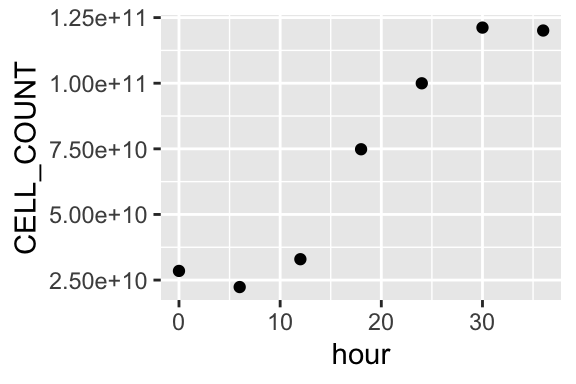

```r
ggplot(summary_table_01, aes(x = hour, y = CELL_COUNT)) +
  geom_point()
```

Repeat cell count

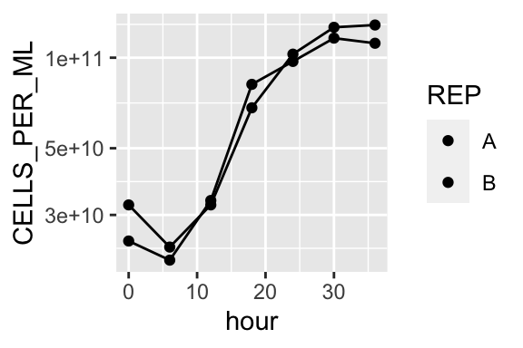

```r
cell_counts_01 %>%
  pivot_longer(cols = starts_with("X"), names_to = "SAMPLE", values_to = "CELL_per_FOV") %>%
  group_by(SAMPLE) %>%
  summarise(MEAN = mean(CELL_per_FOV), VAR = var(CELL_per_FOV)) %>%
  mutate(CELLS_PER_ML = ((MEAN)*(Area_chamber))/((Volume)*(Area_FOV)*(Dilution_factor))) %>%
  mutate(SCI_cells_per_ml = format(CELLS_PER_ML, scientific = TRUE, digits = 3)) %>%
  separate(SAMPLE, into = c("SAMPLE_NAME", "REP"), sep = "_", remove = FALSE) %>%
  mutate(SAMPLE = gsub("X","", SAMPLE)) %>%
  left_join(metadata_01, by = c("SAMPLE" = "sample_id")) %>%
  #
  ggplot(aes(x = hour, y = CELLS_PER_ML, fill = REP)) +
  geom_point() +
  geom_line() +
  scale_y_log10()
```

Modify plot theme:

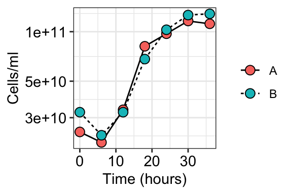

```r
## Data wrangling
cell_counts_01 %>%
  pivot_longer(cols = starts_with("X"), names_to = "SAMPLE", values_to = "CELL_per_FOV") %>%
  group_by(SAMPLE) %>%
  summarise(MEAN = mean(CELL_per_FOV), VAR = var(CELL_per_FOV)) %>%
  mutate(CELLS_PER_ML = ((MEAN)*(Area_chamber))/((Volume)*(Area_FOV)*(Dilution_factor))) %>%
  mutate(SCI_cells_per_ml = format(CELLS_PER_ML, scientific = TRUE, digits = 3)) %>%
  separate(SAMPLE, into = c("SAMPLE_NAME", "REP"), sep = "_", remove = FALSE) %>%
  mutate(SAMPLE = gsub("X","", SAMPLE)) %>%
  left_join(metadata_01, by = c("SAMPLE" = "sample_id")) %>%
# Ggplot code
  ggplot(aes(x = hour, y = CELLS_PER_ML, fill = REP)) +
  geom_line(aes(linetype = REP)) +
  geom_point(shape = 21, color = "black", size = 3) +
  theme_bw() +
  labs(x = "Time (hours)", y = "Cells/ml") +
  theme(axis.text = element_text(size = 11, color = "black"),
        legend.title = element_blank()) +
  scale_y_log10()
```

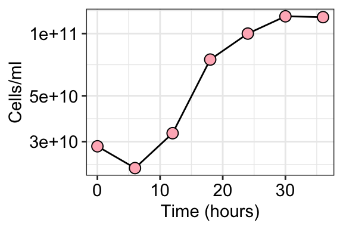

```r
ggplot(summary_table_01, aes(x = hour, y = CELL_COUNT)) +
  geom_line() +
  geom_point(shape = 21, color = "black", size = 3, fill = "lightpink") +
  theme_bw() +
  labs(x = "Time (hours)", y = "Cells/ml") +
  theme(axis.text = element_text(size = 11, color = "black"),
        legend.title = element_blank()) +
  scale_y_log10()
```

#### 2.2.2.2 Growth rate & Generation time

In Excel, calculate growth rate of the monoculture and the generation time.

**Generation time**: internal of time required for the cells to divide (*G*). *t* = time interval, *B* = cells at T0 and *b* = cells at T1, *n* = number of times the cell population doubles during time interval.
$$G = \frac{t}{n}$$
$$b = (B)(2^n)$$
$$n = \frac{logb - logB}{log2}$$
$$G = \frac{t}{3.3(log\frac{b}{B})}$$
We can assume that the best time points to capture generation time during exponential growth are at hour 12 and 30. Calculate the generation time in Excel and then repeat it in R here.

```r
b <- summary_table_01 %>% filter(hour == 30)
b$CELL_COUNT
```

```
## [1] 121195663258
```

```r
B <- summary_table_01 %>% filter(hour == 12)
B$CELL_COUNT
```

```
## [1] 32951816278
```

```r
G_min <- ((30-12)*60)/(3.3*(log10(((b$CELL_COUNT)/(B$CELL_COUNT)))))
G_min
```

```
## [1] 578.6214
```

The gradient of the slope if the growth rate. Isolate 3-4 points from the exponential growth phase. In this case, it is at hours 12, 18, 24, and 30. > In base R, `log()` calculates the natural logarithm.

```r
exp_hour <- c(12, 18, 24, 30)
exp_growth <- summary_table_01 %>%
  filter(hour %in% exp_hour) %>%
  mutate(NAT_LOG = log(CELL_COUNT))
```

Use linear regression and output thee coefficients to determine growth rate.

```r
lm(NAT_LOG ~ hour, exp_growth)
```

```
##
## Call:
## lm(formula = NAT_LOG ~ hour, data = exp_growth)
##
## Coefficients:
## (Intercept)         hour
##    23.55762      0.06994
```

```r
model_output_coefficients <- coef(lm(NAT_LOG ~ hour, exp_growth))
# model_output_coefficients
slope = model_output_coefficients[2]
```

Growth rate (in hours)

```r
slope
```

```
##       hour
## 0.06994376
```

##### 2.2.2.2.1 Exercise: What is the growth rate and doubling time of *bacteria 1*?

# 3 Microbial biodiversity

**Goal**: Establish why assessing microbial biodiversity is important in biological oceanography. Understanding how we can census complex assemblages of microorganisms.

## 3.1 Defining diversity & the biological species concept

## 3.2 Why do we care about diversity?

## 3.3 Amplicons, barcodes, tag-sequencing

### 3.3.1 OTUs vs. ASVs

## 3.4 Import amplicon sequence data

### 3.4.1 Get basic stats

### 3.4.2 Diversity metrics

### 3.4.3 Visualize community composition

### 3.4.4 Additional resources

## 3.5 Interpreting microbial biodiversity

# 4 Hypothesis testing with data sciencee

**Goal**: Gain knowledge in how to compile different data types to address scientific questions.

## 4.1 Spatial & temporal trends in data science

## 4.2 Palmer penguins

Data originates from Kristen Gorman’s work at the Palmer Station LTER. [More information can be found here.](https://allisonhorst.github.io/palmerpenguins/)

- Horst AM, Hill AP, Gorman KB (2020). palmerpenguins: Palmer Archipelago (Antarctica) penguin data. R package version 0.1.0. https://allisonhorst.github.io/palmerpenguins/. doi: 10.5281/zenodo.3960218.

```r
# install.packages("palmerpenguins")
library(palmerpenguins)
# head(penguins)
```

## 4.3 LTER